# Análise das notas do ENEM durante os anos de 2015 e 2019

Matheus Scaketti e João Rabelo

03/12/2021

## Descrição do Tema

A educação no Brasil é discutida constantemente em diversos públicos, além da desigualdade no nível educacional de escolas públicas e privadas, ainda existe a desigualdade entre etnías e renda de cada família brasileira. O ENEM, exame que serve como porta de entrada para o ensino superior, é uma ótima métrica para averiguar como anda o nível de educação dos alunos brasileiros. Sendo assim, o objetivo dessa análise, é verificar, a partir dos dados do ENEM dos anos de 2015 a 2019, como essa desigualdade afeta os estudantes e tentar responder algumas perguntas como: As notas dos alunos estão melhorando no decorrer dos anos? Além da diferença de escola pública e privada, a etnia afeta a nota no ENEM? E a renda?

[figure not shown]

ENEM

[Microdados enem.](https://www.gov.br/inep/pt-br/acesso-a-informacao/dados-abertos/microdados/enem)

## Dataset

Marcados com (*) foram usados no script

- NU_INSCRICAO: Número de inscrição
- (*) NU_ANO: Ano do Enem
- (*) NO_MUNICIPIO_RESIDENCIA: Nome do município de residência
- CO_UF_RESIDENCIA: Código da Unidade da Federação de residência
- (*) SG_UF_RESIDENCIA: Sigla da Unidade da Federação de residência
- TP_DEPENDENCIA_ADM_ESC: Dependência administrativa (Escola)
- TP_LOCALIZACAO_ESC: Localização (Escola)
- TP_SIT_FUNC_ESC: Situação de funcionamento (Escola)
- (*) NU_IDADE: Idade
- (*) TP_SEXO: Sexo
- CO_MUNICIPIO_NASCIMENTO: Código do município de nascimento(1º dígito: Região;1º e 2º dígitos: UF;3º, 4º, 5º e 6º dígitos: Município;7º dígito: dígito verificador)
- (*) TP_ESCOLA: Tipo de escola do Ensino Médio
- TP_ENSINO: Tipo de instituição que concluiu ou concluirá o Ensino Médio
- TP_ESTADO_CIVIL: Estado Civil
- (*) TP_COR_RACA: Cor/raça
- (*) NU_NOTA_CN: Nota da prova de Ciências da Natureza
- (*) NU_NOTA_CH: Nota da prova de Ciências Humanas
- (*) NU_NOTA_LC: Nota da prova de Linguagens e Códigos
- (*) NU_NOTA_MT: Nota da prova de Matemática
- TP_STATUS_REDACAO: Situação da redação do participante
- (*) NU_NOTA_REDACAO: Nota da prova de redação
- (*) Q001: Até que série seu pai, ou o homem responsável por você, estudou?
- (*) Q002: Até que série sua mãe, ou a mulher responsável por você, estudou?
- (*) Q005: Incluindo você, quantas pessoas moram atualmente em sua residência?
- (*) Q006: Qual é a renda mensal de sua família? (Some a sua renda com a dos seus familiares.

## Integrantes

- O que cada um fez.
  - Métricas e Estatísticas básicas: João
  - Filtragens: João
  - Limpeza: João
  - Gráficos: João
  - Testes estatísticos: Matheus/João
  - PCA: Matheus
  - Heatmaps: Matheus
  - Mapa: Matheus
  - Clustering: Matheus
- Maior dificuldade: Escolher qual dataset seria mais apropriado; Manipular os datasets brutos para reduzir o número de indivíduos; Identificar padrões que poderiam criar hipóteses.

## Resultados

```r
library(readxl)
library(dplyr)
library(factoextra)
```

```r
library(pheatmap)
library(gridExtra)
library(grid)
library(reshape2)
library(ggpubr)
library(geobr)
#Read all datasets
df <- read.csv(file="dataset.csv", sep = ";")

cor_pele <- c('Não declarado','Branca',
              'Preta','Parda','Amarela',
              'Indígena','Não dispõe da informação')
escola <- c('Não respondeu', 'Pública', 'Privada')
renda <- c('Nenhuma renda', 'Ate R$ 788', 'R$ 788,01 ate R$ 1.182',
           'De R$ 1.182,01 ate R$ 1.572', 'De R$ 1.572,01 ate R$ 1.970',
           'De R$ 1.970,01 até R$ 2.364', 'De R$ 2.364,01 até R$ 3.152',
           'De R$ 3.152,01 até R$ 3.940', 'De R$ 3.940,01 até R$ 4.728',
           'De R$ 4.728,01 até R$ 5.516', 'De R$ 5.516,01 até R$ 6.304',
           'De R$ 6.304,01 até R$ 7.092', 'De R$ 7.092,01 até R$ 7.880',
           'De R$ 7.880,01 até R$ 9.456', 'De R$ 9.456,01 até R$ 11.820',
           'De R$ 11.820,01 até R$ 15.760', 'Mais de 15.760')
escolaridade <- c('Nunca estudou',
                  'Não completou a 4ª série/5º ano do Ensino Fundamental',
                  'Completou a 4ª série/5º ano, mas não completou a 8ª série/9º ano do Ensino Fundamental',
                  'Completou a 8ª série/9º ano do Ensino Fundamental, mas não completou o Ensino Médio',
                  'Completou o Ensino Médio, mas não completou a Faculdade',
                  'Completou a Faculdade, mas não completou a Pós-graduação',
                  'Completou a Pós-graduação',
                  'Não sei')

df$TP_COR_RACA <- as.factor(df$TP_COR_RACA)
levels(df$TP_COR_RACA) <- cor_pele
df$TP_ESCOLA <- as.factor(df$TP_ESCOLA)
levels(df$TP_ESCOLA) <- escola

df$NU_ANO <- as.factor(df$NU_ANO)
df$Q005 <- as.factor(df$Q005)

#limpando erros
df <- df[df$Q001 != '',]
df$Q001 <- as.factor(df$Q001)
levels(df$Q001) <- escolaridade
df <- df[df$Q002 != '',]
df$Q002 <- as.factor(df$Q002)
levels(df$Q002) <- escolaridade
df <- df[df$Q006 != '',]
df$Q006 <- as.factor(df$Q006)
levels(df$Q006) <- renda

df$NU_NOTA_CH <- df$NU_NOTA_CH/10
df$NU_NOTA_MT <- df$NU_NOTA_MT/10
df$NU_NOTA_CN <- df$NU_NOTA_CN/10
df$NU_NOTA_LC <- df$NU_NOTA_LC/10

df$NU_NOTA_MEDIA <- (df$NU_NOTA_CH+df$NU_NOTA_CN+df$NU_NOTA_LC+df$NU_NOTA_MT+df$NU_NOTA_REDACAO)/5

row.names(df) <- paste0("row_", seq(nrow(df)))

#limpando colunas indesejadas
df <- df[,-c(1,4, 6:8, 11, 13,14,20)]
```

```r
###### 1 - Estatísticas básicas ######
summary(df)
```

```
##   NU_ANO     NO_MUNICIPIO_RESIDENCIA SG_UF_RESIDENCIA      NU_IDADE
##  2015:1494   Length:7494             Length:7494        Min.   :14.00
##  2016:1500   Class :character        Class :character   1st Qu.:17.00
##  2017:1500   Mode  :character        Mode  :character   Median :18.00
##  2018:1500                                              Mean   :19.95
##  2019:1500                                              3rd Qu.:20.00
##                                                         Max.   :65.00
##                                                         NA's   :1
##    TP_SEXO                  TP_ESCOLA                      TP_COR_RACA
##  Length:7494        Não respondeu:2499   Não declarado           : 118
##  Class :character   Pública      :2500   Branca                  :3494
##  Mode  :character   Privada      :2495   Preta                   : 837
##                                          Parda                   :2855
##                                          Amarela                 : 147
##                                          Indígena                :  35
##                                          Não dispõe da informação:   8
##    NU_NOTA_CN      NU_NOTA_CH      NU_NOTA_LC      NU_NOTA_MT
##  Min.   :  0.0   Min.   :  0.0   Min.   :  0.0   Min.   :   0.0
##  1st Qu.:435.4   1st Qu.:493.2   1st Qu.:488.3   1st Qu.: 432.7
##  Median :504.7   Median :572.8   Median :547.5   Median : 518.5
##  Mean   :476.3   Mean   :522.0   Mean   :501.3   Mean   : 505.4
##  3rd Qu.:574.4   3rd Qu.:625.6   3rd Qu.:590.9   3rd Qu.: 629.5
##  Max.   :846.3   Max.   :785.8   Max.   :753.1   Max.   :1002.2
##
##  NU_NOTA_REDACAO
##  Min.   :   0
##  1st Qu.: 520
##  Median : 600
##  Mean   : 619
##  3rd Qu.: 720
##  Max.   :1000
##
##                                                                                      Q001
##  Completou o Ensino Médio, mas não completou a Faculdade                               :2277
##  Não completou a 4ª série/5º ano do Ensino Fundamental                                 :1198
##  Completou a Faculdade, mas não completou a Pós-graduação                              : 904
##  Completou a 8ª série/9º ano do Ensino Fundamental, mas não completou o Ensino Médio   : 900
##  Completou a 4ª série/5º ano, mas não completou a 8ª série/9º ano do Ensino Fundamental: 873
##  Completou a Pós-graduação                                                             : 612
##  (Other)                                                                               : 730
##                                                                                      Q002
##  Completou o Ensino Médio, mas não completou a Faculdade                               :2585
##  Completou a Faculdade, mas não completou a Pós-graduação                              :1180
##  Completou a 8ª série/9º ano do Ensino Fundamental, mas não completou o Ensino Médio   : 943
##  Não completou a 4ª série/5º ano do Ensino Fundamental                                 : 902
##  Completou a Pós-graduação                                                             : 856
##  Completou a 4ª série/5º ano, mas não completou a 8ª série/9º ano do Ensino Fundamental: 763
##  (Other)                                                                               : 265
##       Q005                               Q006      NU_NOTA_MEDIA
##  4      :2626   R$ 788,01 ate R$ 1.182     :1700   Min.   :116.9
##  3      :2015   Ate R$ 788                 :1169   1st Qu.:458.1
##  5      :1171   De R$ 1.182,01 ate R$ 1.572: 783   Median :522.6
##  2      : 868   De R$ 1.572,01 ate R$ 1.970: 736   Mean   :524.8
##  6      : 391   De R$ 2.364,01 até R$ 3.152: 589   3rd Qu.:591.2
##  7      : 153   De R$ 1.970,01 até R$ 2.364: 450   Max.   :838.2
##  (Other): 270   (Other)                    :2067
```

```r
table(df$TP_SEXO, df$TP_COR_RACA)
```

```
##
##     Não declarado Branca Preta Parda Amarela Indígena Não dispõe da informação
##   F            60   2156   498  1708      97       22                        5
##   M            58   1338   339  1147      50       13                        3
```

```r
table(df$TP_ESCOLA, df$TP_COR_RACA)
```

```
##
##                 Não declarado Branca Preta Parda Amarela Indígena
##   Não respondeu            43    939   355  1100      42       18
##   Pública                  30    994   345  1059      58       11
##   Privada                  45   1561   137   696      47        6
##
##                 Não dispõe da informação
##   Não respondeu                        2
##   Pública                              3
##   Privada                              3
```

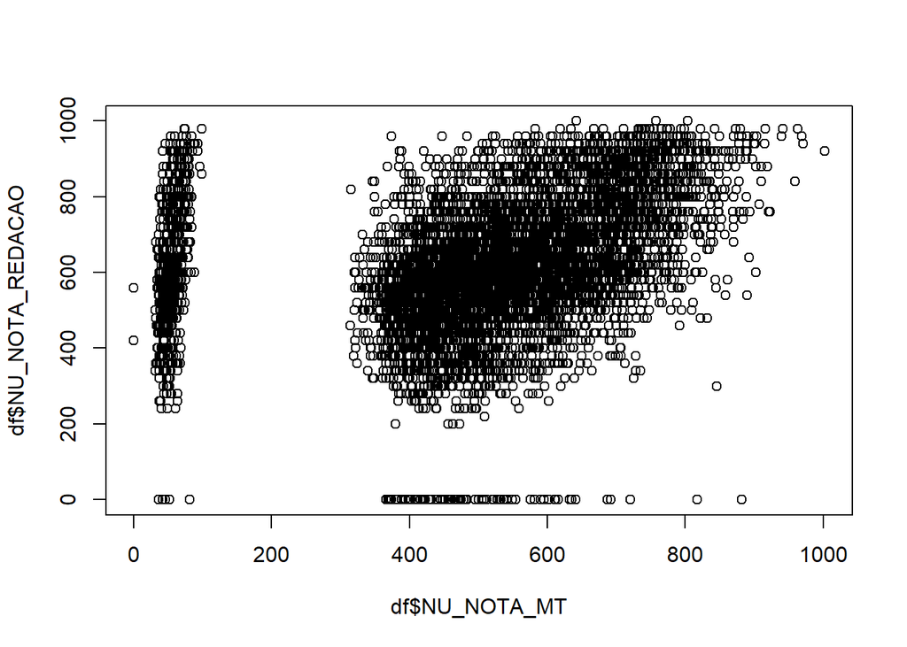

```r
plot(df$NU_NOTA_MT, df$NU_NOTA_REDACAO)
```

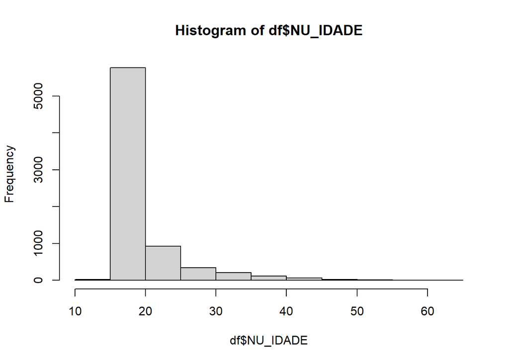

```r
hist(df$NU_IDADE)
```

```r
quantile(na.omit(df$NU_IDADE))
```

```
##   0%  25%  50%  75% 100%
##   14   17   18   20   65
```

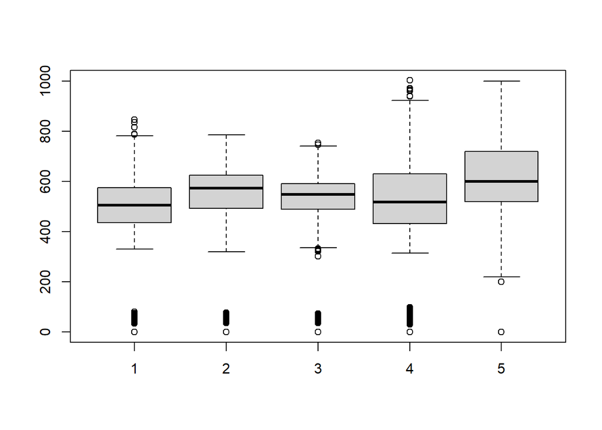

```r
boxplot(df$NU_NOTA_CN, df$NU_NOTA_CH,
        df$NU_NOTA_LC, df$NU_NOTA_MT,
        df$NU_NOTA_REDACAO)
```

```r
###### 2 - Filtragens ######

# retirar na
df_na <- na.omit(df)

df2 <- df_na %>%
  group_by(TP_SEXO, TP_COR_RACA) %>%
  summarise(
    n = n(),
    media_CN = mean(NU_NOTA_CN,
    media_CH = mean(NU_NOTA_CH),
    media_LC = mean(NU_NOTA_LC),
    media_MT = mean(NU_NOTA_MT),
    media_redacao = mean(NU_NOTA_REDACAO)
  ))
df <- df_na %>% filter(TP_ESCOLA != 'Não respondeu') %>%
  filter(TP_COR_RACA != 'Não declarado' & TP_COR_RACA != 'Não dispõe da informação')
```

```r
###### 3 - Limpeza de dados ######
#veriricar se existem NAs
#is.na(df)
table(is.na(df)) # tabela de frequencia
```

```
##
## FALSE
## 83521
```

```r
#Detectando outlier
outlier_values_1 <- boxplot.stats(df$NU_NOTA_REDACAO)$out
outlier_values_2 <- boxplot.stats(df$NU_NOTA_CN)$out
outlier_values_3 <- boxplot.stats(df$NU_NOTA_CH)$out
outlier_values_4 <- boxplot.stats(df$NU_NOTA_LC)$out
outlier_values_5 <- boxplot.stats(df$NU_NOTA_MT)$out

#verifica
library(EnvStats)
test <- rosnerTest(df$NU_NOTA_REDACAO,k=length(outlier_values_1),alpha = 0.05)
test <- rosnerTest(df$NU_NOTA_CN,k=length(outlier_values_2),alpha = 0.05)
test <- rosnerTest(df$NU_NOTA_CH,k=length(outlier_values_3),alpha = 0.05)
test <- rosnerTest(df$NU_NOTA_LC,k=length(outlier_values_4),alpha = 0.05)
test <- rosnerTest(df$NU_NOTA_MT,k=length(outlier_values_5),alpha = 0.05)
outliers <- unique(c(outlier_values_1, outlier_values_2,
                     outlier_values_3, outlier_values_4, outlier_values_5))

#retira outliers de todas as colunas de notas
df_clean <- df[-which(df$NU_NOTA_REDACAO %in% outlier_values_1 |
                      df$NU_NOTA_CN %in% outlier_values_2 |
                      df$NU_NOTA_CH %in% outlier_values_3 |
                      df$NU_NOTA_LC %in% outlier_values_4 |
                      df$NU_NOTA_MT %in% outlier_values_5),]
```

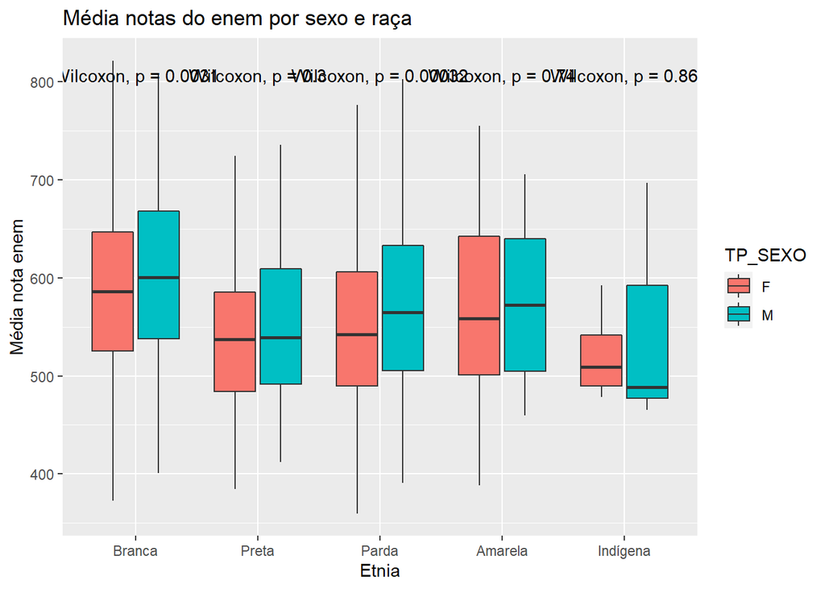

```r
###### 4 - Gráficos ######

ggplot(data = df_clean, aes(x=TP_COR_RACA, y=NU_NOTA_MEDIA,fill=TP_SEXO)) +
  geom_boxplot(outlier.shape = NA)+
  xlab("Etnia")+ylab("Média nota enem")+ggtitle("Média notas do enem por sexo e raça")+
  stat_compare_means(label.y = c(800),
                     method = "wilcox.test",paired = FALSE)
```